# Code

## Step 1: Logistic Regression (First Attempt)

Our analysis begins by fitting a comprehensive logistic regression model.

The goal is to identify the primary socio-economic and demographic predictors of a household being in relative poverty (`Is_Poor`).

```python
df = pd.read_csv("Tehran_all_prepared.csv")
```

```python
controls = "Aid_Income_Share + Pension_Income_Share + Capital_Income_Share + Imputed_Rent_Share + Other_NonCash_Income_Share + C(Tenure_Type) + C(Year) + C(Urban_Rural)"
demographics = "C(Head_Age) + C(Head_Education_Level) + C(Head_Activity_Status) + C(Head_Sex) + C(Head_Marital_Status)"
household_structure = "C(Household_Size) + Dependency_Ratio_Employment"

run_analysis(df, [0.6], 0.05, controls, demographics, household_structure)
```

```
========================================================================================================================
ANALYSIS FOR POVERTY LINE: 60% of Median by Alpha of 0.05
========================================================================================================================
Poverty line for year 1399 (60%): 236,776,000.00
Poverty line for year 1400 (60%): 353,113,043.48
Poverty line for year 1401 (60%): 516,351,910.00
========================================================================================================================
Optimization terminated successfully.
         Current function value: 0.435718
         Iterations 8
========================================================================================================================

                                           feature        VIF
0                                        Intercept  40.815196
1                             C(Head_Age)[T.20-30]   1.223678
2                             C(Head_Age)[T.30-40]   1.610561
3                             C(Head_Age)[T.50-60]   1.783877
4                             C(Head_Age)[T.60-70]   2.231262
5                          C(Head_Age)[T.Above 70]   2.607860
6              C(Head_Education_Level)[T.Bachelor]   1.375288
7            C(Head_Education_Level)[T.Illiterate]   1.753862
8           C(Head_Education_Level)[T.Masters_PhD]   1.217233
9         C(Head_Education_Level)[T.Under_Diploma]   1.715438
10          C(Head_Activity_Status)[T.Housekeeper]   1.758833
11  C(Head_Activity_Status)[T.Income_without_Work]   4.246159
12                C(Head_Activity_Status)[T.Other]   1.173358
13           C(Head_Activity_Status)[T.Unemployed]   1.141024
14                           C(Head_Sex)[T.Female]   3.427335
15              C(Head_Marital_Status)[T.Bachelor]   1.304578
16              C(Head_Marital_Status)[T.Divorced]   1.571514
17               C(Head_Marital_Status)[T.Widowed]   3.613936
18                          C(Household_Size)[T.2]   3.776756
19                          C(Household_Size)[T.3]   5.634609
20                          C(Household_Size)[T.4]   7.792705
21                          C(Household_Size)[T.5]   4.286138
22                          C(Household_Size)[T.6]   1.980387
23                          C(Household_Size)[T.7]   1.386261
24                    C(Household_Size)[T.Above 7]   1.196539
25                         C(Tenure_Type)[T.Other]   2.334578
26                        C(Tenure_Type)[T.Tenant]   1.334124
```

[output cut: 51 more lines]

```
C(Tenure_Type)[T.Other]                       -1.4465      0.2354          -0.2050   0.0000
C(Head_Education_Level)[T.Masters_PhD]        -1.8880      0.1514          -0.2675   0.0000

========================================================================================================================
--- Goodness-of-Fit Statistics ---
Observations:          4,275
Pseudo R-squared:      0.2968 (McFadden's)
Log-Likelihood:        -1,862.70
AIC:                   3,797.39
BIC:                   4,026.37
Hosmer-Lemeshow Test:
Chi-squared   24.3468942308
p-value        0.0020040244
df             8.0000000000
========================================================================================================================
```

## Step 2: Logistic Regression (Second Attempt)

Now, we remove some features:

- `Head_Sex`
- `Head_Marital_Status`
- `Household_Size`

We expect to get better results. Let's See!

```python
controls = "Aid_Income_Share + Pension_Income_Share + Capital_Income_Share + Imputed_Rent_Share + Other_NonCash_Income_Share + C(Tenure_Type) + C(Urban_Rural)"
demographics = "C(Head_Age) + C(Head_Education_Level) + C(Head_Activity_Status)"
household_structure = "Dependency_Ratio_Employment"

run_analysis(df, [0.6], 0.05, controls, demographics, household_structure)
```

```
========================================================================================================================
ANALYSIS FOR POVERTY LINE: 60% of Median by Alpha of 0.05
========================================================================================================================
Poverty line for year 1399 (60%): 236,776,000.00
Poverty line for year 1400 (60%): 353,113,043.48
Poverty line for year 1401 (60%): 516,351,910.00
========================================================================================================================
Optimization terminated successfully.
         Current function value: 0.436872
         Iterations 8
========================================================================================================================

                                           feature        VIF
0                                        Intercept  14.028896
1                             C(Head_Age)[T.20-30]   1.163051
2                             C(Head_Age)[T.30-40]   1.532438
3                             C(Head_Age)[T.50-60]   1.744641
4                             C(Head_Age)[T.60-70]   2.167239
5                          C(Head_Age)[T.Above 70]   2.497287
6              C(Head_Education_Level)[T.Bachelor]   1.365845
7            C(Head_Education_Level)[T.Illiterate]   1.653602
8           C(Head_Education_Level)[T.Masters_PhD]   1.204821
9         C(Head_Education_Level)[T.Under_Diploma]   1.686215
10          C(Head_Activity_Status)[T.Housekeeper]   1.386109
11  C(Head_Activity_Status)[T.Income_without_Work]   3.869396
12                C(Head_Activity_Status)[T.Other]   1.162529
13           C(Head_Activity_Status)[T.Unemployed]   1.121706
14                         C(Tenure_Type)[T.Other]   2.316440
15                        C(Tenure_Type)[T.Tenant]   1.290604
16                         C(Urban_Rural)[T.Urban]   1.189573
17                     Dependency_Ratio_Employment   1.208724
18                                Aid_Income_Share   2.256014
19                            Pension_Income_Share   3.206153
20                            Capital_Income_Share   1.277976
21                              Imputed_Rent_Share   2.154841
22                      Other_NonCash_Income_Share   1.263758

========================================================================================================================
--- Non-Significant Features (p >= 0.05) ---
                                                p_value
```

[output cut: 25 more lines]

```
C(Tenure_Type)[T.Other]                       -1.4532      0.2338          -0.2066   0.0000
C(Head_Education_Level)[T.Masters_PhD]        -1.8841      0.1520          -0.2679   0.0000

========================================================================================================================
--- Goodness-of-Fit Statistics ---
Observations:          4,275
Pseudo R-squared:      0.2949 (McFadden's)
Log-Likelihood:        -1,867.63
AIC:                   3,781.25
BIC:                   3,927.54
Hosmer-Lemeshow Test:
Chi-squared   22.8047649213
p-value        0.0036241601
df             8.0000000000
========================================================================================================================
```

## Step 3: Logistic Regression (Third Attempt)

This time, instead of categorical `Head_Age` we use the numerical data (`Head_Age_`).

But we also include `Head_Age ** 2` according to social studies.

Let's see if it makes the analysis better!

```python
controls = "Aid_Income_Share + Pension_Income_Share + Capital_Income_Share + Imputed_Rent_Share + Other_NonCash_Income_Share + C(Tenure_Type) + C(Urban_Rural)"
demographics = "Head_Age_ + I(Head_Age_ ** 2) + C(Head_Education_Level) + C(Head_Activity_Status)"
household_structure = "Dependency_Ratio_Employment"

run_analysis(df, [0.6], 0.05, controls, demographics, household_structure)
```

```
========================================================================================================================
ANALYSIS FOR POVERTY LINE: 60% of Median by Alpha of 0.05
========================================================================================================================
Poverty line for year 1399 (60%): 236,776,000.00
Poverty line for year 1400 (60%): 353,113,043.48
Poverty line for year 1401 (60%): 516,351,910.00
========================================================================================================================
Optimization terminated successfully.
         Current function value: 0.436745
         Iterations 8
========================================================================================================================

                                           feature        VIF
0                                        Intercept  11.968557
1              C(Head_Education_Level)[T.Bachelor]   1.365565
2            C(Head_Education_Level)[T.Illiterate]   1.650137
3           C(Head_Education_Level)[T.Masters_PhD]   1.204194
4         C(Head_Education_Level)[T.Under_Diploma]   1.688301
5           C(Head_Activity_Status)[T.Housekeeper]   1.379251
6   C(Head_Activity_Status)[T.Income_without_Work]   3.791690
7                 C(Head_Activity_Status)[T.Other]   1.159134
8            C(Head_Activity_Status)[T.Unemployed]   1.118632
9                          C(Tenure_Type)[T.Other]   2.313197
10                        C(Tenure_Type)[T.Tenant]   1.292573
11                         C(Urban_Rural)[T.Urban]   1.187313
12                                       Head_Age_   2.269836
13                               I(Head_Age_ ** 2)   1.153528
14                     Dependency_Ratio_Employment   1.139180
15                                Aid_Income_Share   2.254977
16                            Pension_Income_Share   3.196280
17                            Capital_Income_Share   1.279292
18                              Imputed_Rent_Share   2.177930
19                      Other_NonCash_Income_Share   1.262815

========================================================================================================================
--- Non-Significant Features (p >= 0.05) ---
                                                p_value
C(Head_Activity_Status)[T.Income_without_Work]    0.206
I(Head_Age_ ** 2)                                 0.070
Aid_Income_Share                                  0.288
```

[output cut: 19 more lines]

```
C(Tenure_Type)[T.Other]                       -1.4675      0.2305          -0.2085   0.0000
C(Head_Education_Level)[T.Masters_PhD]        -1.8879      0.1514          -0.2683   0.0000

========================================================================================================================
--- Goodness-of-Fit Statistics ---
Observations:          4,275
Pseudo R-squared:      0.2951 (McFadden's)
Log-Likelihood:        -1,867.09
AIC:                   3,774.17
BIC:                   3,901.38
Hosmer-Lemeshow Test:
Chi-squared   23.5069544938
p-value        0.0027708469
df             8.0000000000
========================================================================================================================
```

## Step 5: Semi-Parametric Modeling - Generalized Additive Model (GAM)

The final logistic regression model failed the Hosmer-Lemeshow goodness-of-fit test, indicating that the model's linear assumptions do not fully capture the underlying data patterns. To overcome this limitation, we now fit a **Generalized Additive Model (GAM)**.

GAMs extend generalized linear models by allowing for non-linear relationships between predictors and the outcome. This is achieved using:

- **Smooth terms `s()`**: For continuous variables, allowing the data to determine the shape of the relationship.
- **Factor terms `f()`**: For categorical variables.

```python
# Import libraries needed for this task
import pandas as pd
import numpy as np
from pygam import LogisticGAM, s, f
from sklearn.preprocessing import StandardScaler
import matplotlib.pyplot as plt
import seaborn as sns # For a nicer style
import warnings

warnings.filterwarnings('ignore')

# --------------------------------------------------------------------
# Helper Functions (Unchanged)
# --------------------------------------------------------------------
def weighted_median(data, weights):
    df_temp = pd.DataFrame({'data': data, 'weights': weights}).dropna()
    df_temp = df_temp.sort_values('data')
    df_temp['cumulative_weight'] = df_temp['weights'].cumsum()
    total_weight = df_temp['weights'].sum()
    median_value = df_temp['data'][df_temp['cumulative_weight'] >= total_weight / 2].iloc[0]
    return median_value

# --------------------------------------------------------------------
# Data Preparation (Corrected)
# --------------------------------------------------------------------
def prepare_data(pp=0.6):
    df = pd.read_csv("Tehran_all_prepared.csv")

    # Ensure correct data types for calculation
    df['Net_Expenditure'] = pd.to_numeric(df['Net_Expenditure'], errors='coerce')
    df['OECD_Modified'] = pd.to_numeric(df['OECD_Modified'], errors='coerce')

    df.loc[:, 'Equivalized_Net_Expenditure'] = df['Net_Expenditure'] / df['OECD_Modified']
    df = df.drop(columns=['Net_Expenditure', 'OECD_Modified'])
    df = df.dropna(subset=['Equivalized_Net_Expenditure', 'Household_Weight'])

    # Yearly loop to define poverty
    yearly_dfs = []
    for year in sorted(df['Year'].unique()):
        df_year = df[df['Year'] == year].copy()
        median_expenditure = weighted_median(data=df_year['Equivalized_Net_Expenditure'], weights=df_year['Household_Weight'])
        poverty_line = pp * median_expenditure
        df_year['Is_Poor'] = (df_year['Equivalized_Net_Expenditure'] < poverty_line).astype(int)
        yearly_dfs.append(df_year)
    df = pd.concat(yearly_dfs)

    # Define features
    numerical_features = ['Aid_Income_Share', 'Labor_Income_Share', 'Pension_Income_Share', 'Capital_Income_Share', 'Imputed_Rent_Share', 'Other_NonCash_Income_Share', 'Dependency_Ratio_Employment', 'Head_Age_']
    categorical_features = ['Head_Education_Level', 'Head_Activity_Status', 'Tenure_Type', 'Urban_Rural']

    # Drop rows with NaNs in feature columns
    df = df.dropna(subset=numerical_features + categorical_features)

    # Scale numerical features
    scaler = StandardScaler()
    df[numerical_features] = scaler.fit_transform(df[numerical_features])

    # Set categorical features
    for col in categorical_features:
        df[col] = pd.Categorical(df[col])

    return df, scaler, numerical_features, categorical_features

# --------------------------------------------------------------------
# Plotting Function (CORRECTED)
# --------------------------------------------------------------------
def plot_gam_results(gam, df, features, numerical_features, scaler):
    """
    Generates and saves partial dependence plots for a fitted GAM model.
    - Correctly handles numerical vs. categorical plotting logic.
    - Simplifies and corrects the logic for categorical features.
    - Sorts categorical features by their effect for better interpretability.
    """
    print("\nGenerating partial dependence plots with LOG-ODDS axes...")

    n_features = len(features)
    n_cols = 3
    n_rows = int(np.ceil(n_features / n_cols))

    fig, axs = plt.subplots(n_rows, n_cols, figsize=(n_cols * 6, n_rows * 5))
    fig.suptitle('Regularized GAM Partial Dependence Plots', fontsize=18, y=1.02)

    axs = axs.flatten()

    for i, feature_name in enumerate(features):
        ax = axs[i]

        if feature_name in numerical_features:
            # --- Logic for Numerical Features (Splines) ---
            XX = gam.generate_X_grid(term=i, n=100)
            pdep, confi = gam.partial_dependence(term=i, X=XX, width=0.95)
            pdep = np.exp(pdep)
            confi = np.exp(confi)

            # Create a dummy array to inverse-transform the feature's values
            # to their original scale for plotting.
            dummy_scaled_data = np.zeros((XX.shape[0], len(numerical_features)))
            feature_idx_in_scaler = numerical_features.index(feature_name)
            dummy_scaled_data[:, feature_idx_in_scaler] = XX[:, i]
            unscaled_full_data = scaler.inverse_transform(dummy_scaled_data)
            unscaled_x = unscaled_full_data[:, feature_idx_in_scaler]

            ax.plot(unscaled_x, pdep, color='darkblue', linewidth=2.5)
            ax.fill_between(unscaled_x.ravel(), confi[:, 0], confi[:, 1], color='lightblue', alpha=0.4)
            ax.set_xlabel(feature_name.replace('_', ' '), fontsize=12) # Set x-label for numerical

        else:
            # --- CORRECTED Logic for Categorical Features (Factors) ---
            # 1. Get the original category names. They are ordered in a way that
            #    corresponds to the integer codes (0, 1, 2, ...) used by the model.
            categories = df[feature_name].cat.categories

            # 2. Generate a grid for the feature and compute its partial dependence.
            #    The results (pdep, confi) are ordered by the category codes.
            XX = gam.generate_X_grid(term=i)
            pdep, confi = gam.partial_dependence(term=i, X=XX, width=0.95)

            # 3. Create a DataFrame to hold the results, linking category names to their effects.
            effect_df = pd.DataFrame({
                'category': categories,
                'pdep': pd.unique(pdep),
                'confi_lower': pd.unique(confi[:, 0]),
                'confi_upper': pd.unique(confi[:, 1])
            })
            cols_to_transform = ['pdep', 'confi_lower', 'confi_upper']
            effect_df[cols_to_transform] = effect_df[cols_to_transform].apply(np.exp)

            if feature_name in ['Head_Education_Level', 'Head_Activity_Status', 'Tenure_Type']:
                effect_df = effect_df.sort_values('pdep', ascending=False) # Sort by effect size for interpretability

            # 4. Plot using a simple integer range for the x-axis.
            x_range = np.arange(len(effect_df))
            ax.plot(x_range, effect_df['pdep'], 'o-', color='darkblue', linewidth=2.5, markersize=8)
            ax.fill_between(x_range, effect_df['confi_lower'], effect_df['confi_upper'], color='lightblue', alpha=0.4)

            # 5. Set the ticks and labels using the sorted category names.
            ax.set_xticks(x_range)
            ax.set_xticklabels(effect_df['category'], rotation=45, ha='right', fontsize=10)
            ax.set_xlabel('') # Clear x-label for categorical for tidiness

        ax.set_title(feature_name.replace('_', ' '), fontsize=14)
        ax.set_ylabel('Odds Ratio on Poverty', fontsize=12)
        ax.axhline(y=1, linestyle='--', color='red', linewidth=1)
        ax.grid(True, linestyle='--', alpha=0.6)

    # Hide any unused subplots
    for j in range(i + 1, len(axs)):
        axs[j].set_visible(False)

    plt.tight_layout(rect=[0, 0, 1, 0.98])
    plt.show()

# --------------------------------------------------------------------
# Main Analysis Function (Corrected and Integrated)
# --------------------------------------------------------------------
def generate_terms(features, numericals):
    gam_terms = []
    for i, feature in enumerate(features):
        if feature in numericals:
            gam_terms.append(s(i))
        else:
            gam_terms.append(f(i))

    # Start with the first term and add the rest
    gam_formula = gam_terms[0]
    for i in range(1, len(gam_terms)):
        gam_formula += gam_terms[i]

    return gam_formula

def run_gam_analysis():
    print("="*80)
    print("Running REGULARIZED GAM Analysis")
    print("="*80)

    df, scaler, numerical_features, categorical_features = prepare_data()

    features = numerical_features + categorical_features

    X = df[features].copy()
    # Convert only categorical columns to codes for the model
    for col in categorical_features:
        X[col] = X[col].cat.codes

    y = df['Is_Poor'].values
    weights = df['Household_Weight'].values

    # --- Build the formula dynamically ---
    gam_formula = generate_terms(features, numerical_features)

    print("\nFitting GAM model using gridsearch for optimal smoothing...")
    lams = np.exp(np.random.random((15, len(features))) * 6 - 3)
    gam = LogisticGAM(gam_formula).gridsearch(X.values, y, weights=weights, lam=lams)
    print("Model fitting complete.\n")

    gam.summary()

    return gam, df, features, numerical_features, scaler
```

```python
gam, df, features, numerical_features, scaler = run_gam_analysis()
```

[output not shown]

```
================================================================================
Running REGULARIZED GAM Analysis
================================================================================

Fitting GAM model using gridsearch for optimal smoothing...
```

[output not shown]

```
Model fitting complete.

LogisticGAM
=============================================== ==========================================================
Distribution:                      BinomialDist Effective DoF:                                    148.0481
Link Function:                        LogitLink Log Likelihood:                                 -2407.7669
Number of Samples:                         5823 AIC:                                               5111.63
                                                AICc:                                            5119.5146
                                                UBRE:                                            1560.3089
                                                Scale:                                                 1.0
                                                Pseudo R-Squared:                                   0.4134
==========================================================================================================
Feature Function                  Lambda               Rank         EDoF         P > x        Sig. Code
================================= ==================== ============ ============ ============ ============
s(0)                              [2.1407]             20           18.9         0.00e+00     ***
s(1)                              [0.1762]             20           18.9         0.00e+00     ***
s(2)                              [0.1197]             20           18.8         0.00e+00     ***
s(3)                              [1.1212]             20           17.1         0.00e+00     ***
s(4)                              [0.1147]             20           18.4         0.00e+00     ***
s(5)                              [0.052]              20           14.4         0.00e+00     ***
s(6)                              [9.725]              20           11.7         0.00e+00     ***
s(7)                              [0.2212]             20           18.9         0.00e+00     ***
f(8)                              [0.0609]             5            4.0          0.00e+00     ***
f(9)                              [5.9474]             5            4.0          0.00e+00     ***
f(10)                             [6.2969]             3            2.0          0.00e+00     ***
f(11)                             [0.3831]             2            1.0          0.00e+00     ***
intercept                                              1            0.0          0.00e+00     ***
==========================================================================================================
Significance codes:  0 '***' 0.001 '**' 0.01 '*' 0.05 '.' 0.1 ' ' 1

WARNING: Fitting splines and a linear function to a feature introduces a model identifiability problem
         which can cause p-values to appear significant when they are not.

WARNING: p-values calculated in this manner behave correctly for un-penalized models or models with
         known smoothing parameters, but when smoothing parameters have been estimated, the p-values
         are typically lower than they should be, meaning that the tests reject the null too readily.
```

```python
gam.coef_[-1]
```

```
62.719750860709176
```

```
Generating partial dependence plots with LOG-ODDS axes...
```

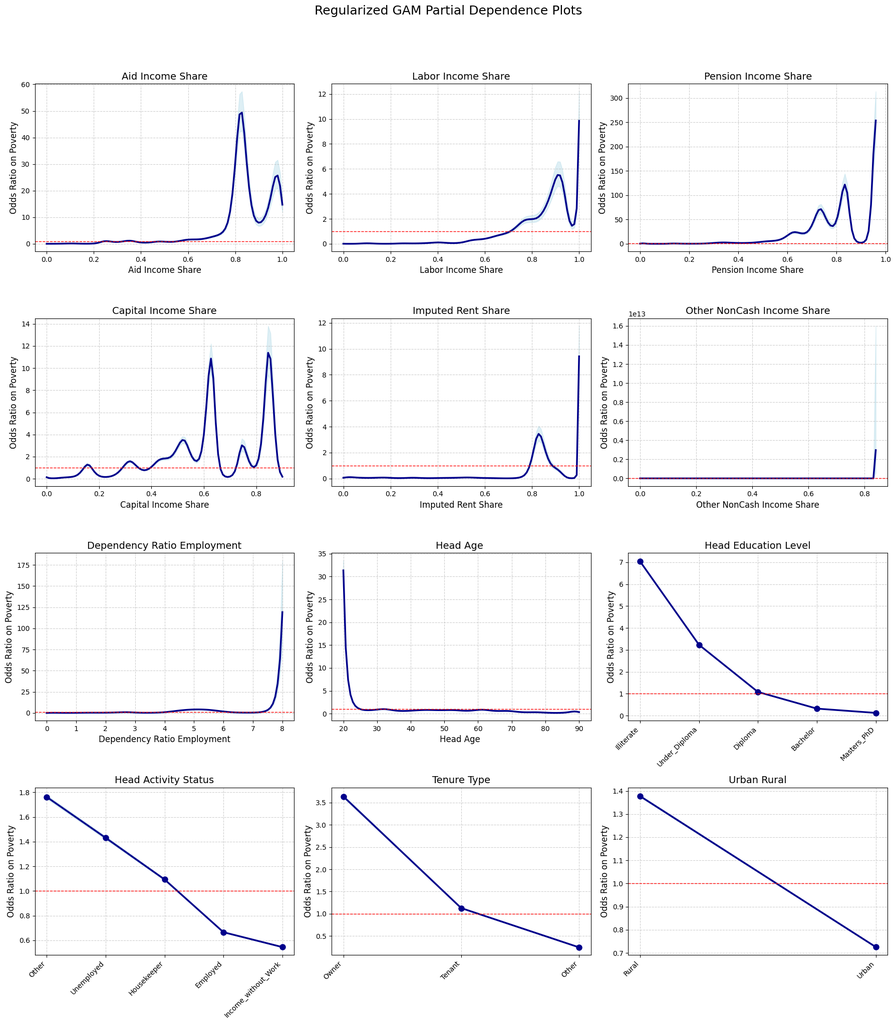

```python
plot_gam_results(gam, df, features, numerical_features, scaler)
```